# ESM 244 - HW 3 - Task 1

Author

Lauren Puffer

## Overview

For this analysis we will be using stream chemistry data collected from watersheds in Santa Barbara starting in 2000 to observe how dissimilar different sites are based on their amounts of ammonium (micromoles per liter), nitrate (micromoles per liter), phosphate (micromoles per liter), total dissolved nitrogen (micromoles per liter), total dissolved phosphorous (micromoles per liter) and specific conductivity (micro-Siemens per cm). The dataset we are working on comes from the Santa Barbara County Long-Term Ecological Research project (SBC LTER), which means that data collection for this dataset is ongoing. We will be using hierarchical agglomarative clustering with complete linkages to determine dissimilarity between sites. The final product of this anaylsis will be a dendrogram to visualize the euclidian distance between sites, representing a certain degree of dissimilarity.

## Load packages

```r
#packages for data organiztaion
library(tidyverse)
library(janitor)
library(here)

#packages for clustering
library(NbClust)
library(cluster)
library(factoextra)
library(dendextend)
library(ggdendro)
```

## Citation

Santa Barbara Coastal LTER and J. Melack. 2019. SBC LTER: Land: Stream chemistry in the Santa Barbara Coastal drainage area, ongoing since 2000 ver 16. Environmental Data Initiative. https://doi.org/10.6073/pasta/67a558a24ceed9a0a5bf5e46ab841174.

## Pseudocode

1. Load data and change -999 to NA. Ensure that variables are numeric.
2. Drop NAs using column deletion, then list deletion
3. Include only numeric data.
4. Scale data.
5. Distance of scaled data.
6. Use hclust to sort into clusters.
7. Get correlation between clusters using complete linkages
8. Create dendrogram to observe similarity of sites.

## Load stream chemistry data

The people who made this data set used -999 to convey a value where data is missing. We will change those values to NAs in our data wrangling. We will then take a look at our data to see how many NAs we have. Our agglomerative hierarchical cluster will also only work with numeric data. To ensure that all of the variables we use are being passed as numeric values we will convert them to numeric data.

```r
#load data from local file in R project
stream_data <- read.csv(here("data", "sbc_lter_registered_stream_chemistry.csv"))

#data wrangling: group by site and collect mean for clustering

#when we examine data in our console with the 'summary()' function, we see that there are -999 values for the minimum of many of our variables. This is how NAs are defined. We need to change the -999 values to NAs using the 'mutate()' function.

stream_data <- read.csv(here("data","sbc_lter_registered_stream_chemistry.csv"),
                     na = '-999') |>
  clean_names()|>
  select(-timestamp_local)

#make sure columns with numeric data are being interpreted as numeric

#name columns to be used as numeric
cols_to_convert <- c("nh4_u_m", "no3_u_m", "po4_u_m", "tdn_u_m",
                     "tdp_u_m", "tpc_u_m", "tpn_u_m", "tss_mgper_liter",
                     "spec_cond_u_spercm")

#take these columns and convert them to numeric data
stream_data[cols_to_convert] <- lapply(stream_data[cols_to_convert], as.numeric)

#rtest one column to see if it's numeric
is.numeric(stream_data$nh4_u_m)
```

```
[1] TRUE
```

```r
#it worked!
```

## Deleting NAs

Because we have so many NAs in our dataset, we will need to get rid of as many NAs as possible, without deleting most of our usable data. To do this, we will first create a cut off for the amount of NAs a column should have. In this case, 9000 is selected because that is roughly 50% of our observations. Any column with greater than 9000 NAs will be dropped from the data set. Then we will perform a list deletion using drop_na() to get rid of the remainder of our NAs. The reason we are doing it in this order, is because if we only conducted a list deletion, we would have much fewer observations. We want to use as many observations as possible in our analysis for the sake of accuracy.

```r
#Because there are many NAs in our dataframe but we don't want to exclude too much data, we will do deletion of columns with >50 NAs. na_count <- colSums(is.na(df))

na_count <- colSums(is.na(stream_data))

#columns with more than 50% NAs
cols_to_remove <- names(na_count[na_count > 9000])

#remove columns with >50% NAs from the data frame
stream_col_clean <- stream_data[, !(names(stream_data) %in% cols_to_remove)]

#drop NAs
stream_clean <- stream_col_clean |>
  drop_na()
```

## Data frame with means for each site

The data frame we are going to make must contain the mean values of each variable for each site. This is because we need to be able to assess similarity on a site-by-site basis, not based on different observations.

```r
stream_summary <-  stream_clean|>
  group_by(site_code) |>
  summarize(across(where(is.numeric), ~ mean(.x, na.rm = TRUE)))
```

## Scaling data

Scaling ensures that all of our features are equally contributing to our analysis. This prevents variables with greater ranges from skewing our clusters in one way or another. In order to scale our data we must extract only the numeric values by removing non-numeric data. After we are done scaling, we will replace our site names.

```r
#Scale the numeric variables (columns 3:7)
stream_scaled <- stream_summary |>
  select(where(is.numeric))|>
  scale()

#put row names for site back into the dataframe
rownames(stream_scaled) <- stream_summary$site_code
```

## Calculating Euclidian distance

This allows us to collect a specific measure of dissimilarity between each site based on our water chemistry variables. The values generated for euclidian distance will be the same values we will use to populate our dendrogram.

```r
#used vector of scaled data to calculate euclidian distance
euc_dist <- dist(stream_scaled, method= 'euclidian')
```

## Complete linkage hierarchical clustering

Complete linkage clustering uses the maximum distance between the farthest points and compares it with the distance between clusters to define its linkages. The result gives us compact clusters that are clearly defined.

```r
#Hierarchical clustering (complete linkage)
comp_hclust_stream <- hclust(euc_dist, method = "complete" )
```

## Create dendrogram

Dendrograms are used to compare clusters of data points. In this case we will be comparing sites based on their water quality data.

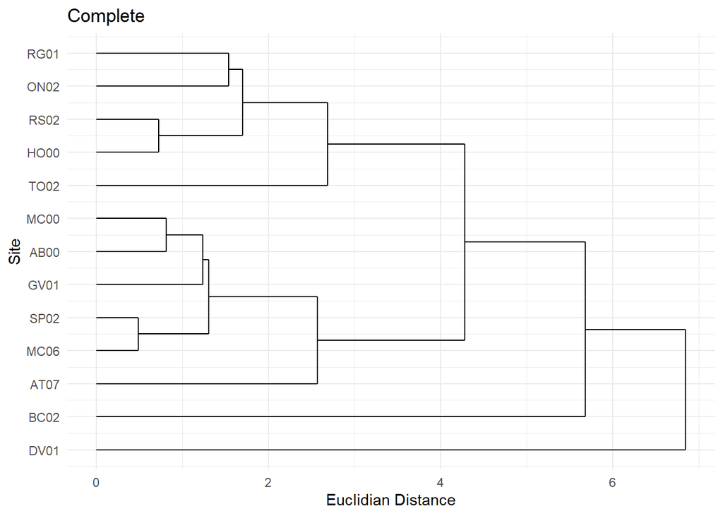

Fig. 1 - This dendrogram shows dissimilarity as a function of euclidian distance. An increase in euclidian distance corresponds to increased dissimilarity between sites.

```r
#Plot dendrogram
hclust_dend_stream<-ggdendrogram(comp_hclust_stream,
             rotate = TRUE) + #rotates 90
  theme_minimal() +
  labs(title= "Complete", x = "Site", y = "Euclidian Distance")

hclust_dend_stream
```

## Discussion

Sites RG01, ON02, RS02, and HO00 are similar to one another based on their low euclidian distance and closeness to on another. Sites MC00, AB00, GV01, SP02, and MC06 are also similar. The similarity between sites based on their water quality suggests that they may have similar inputs for water, species within them, and provide similar ecosystem services. For this analysis we used ammonium, nitrate, phosphate, specific conductivity, total dissolved nitrogen, and total dissolved phosphate. All of these variables could tell use something about the kinds of things living in each site and how similar those groups of organisms are between sites. Living things on Earth require certain amounts of nutrients like nitrate, phosphate, and even ammonium. Further analysis could examine this relationship between water quality and species composition at each site.